# Final Project

## Introduction:

The following is a story, regarding NY Emergency Incidents in relation to Queens, NY, by main and sub categories.

## Import:

```r
# Loading Data
my_data <- read_csv("https://data.cityofnewyork.us/resource/pasr-j7fb.csv")
head(my_data)
```

```
## # A tibble: 6 x 7
##   incident_type location borough creation_date       closed_date
##   <chr>         <chr>    <chr>   <dttm>              <dttm>
## 1 Utility-Wate… 136-17 … Queens  2017-01-16 13:13:38 NA
## 2 Structural-S… 927 Bro… Manhat… 2016-10-29 12:13:31 NA
## 3 Utility-Other <NA>     Manhat… 2016-11-22 08:53:17 NA
## 4 Administrati… Seagirt… Queens  2016-11-14 15:53:54 NA
## 5 Law Enforcem… <NA>     Brookl… 2016-10-29 17:35:28 NA
## 6 Utility-Wate… 2-17 54… Queens  2016-12-02 16:40:13 NA
## # … with 2 more variables: latitude <dbl>, longitude <dbl>
```

## Tidy:

```r
# Creating Factors Based in Incident Type
my_data = my_data %>%
  separate(incident_type, c("incident_type_main", "incident_type_sub"), "-")
# Adjusting Borough Names

# Capitalization
my_data$borough = sub('new york', 'New York', my_data$borough)
my_data$borough = sub('queens', 'Queens', my_data$borough)
my_data$borough = sub('bronx', 'Bronx', my_data$borough)
my_data$borough = sub('manhattan', 'Manhattan', my_data$borough)
my_data$borough = sub('Staten ISland', 'Staten Island', my_data$borough)


# Converting to Neighborhoods to Boroughs
my_data$borough = sub('Far Rockaway', 'Queens', my_data$borough)
my_data$borough = sub('Jamaica', 'Queens', my_data$borough)
my_data$borough = sub('Richmond Hill', 'Queens', my_data$borough)
```

```r
# Dropping Boroughs equal to New York
my_data = subset(my_data, borough != 'New York')
```

## Explore, model, visualize:

### 1. Which boroughs had the least emergency incidents?

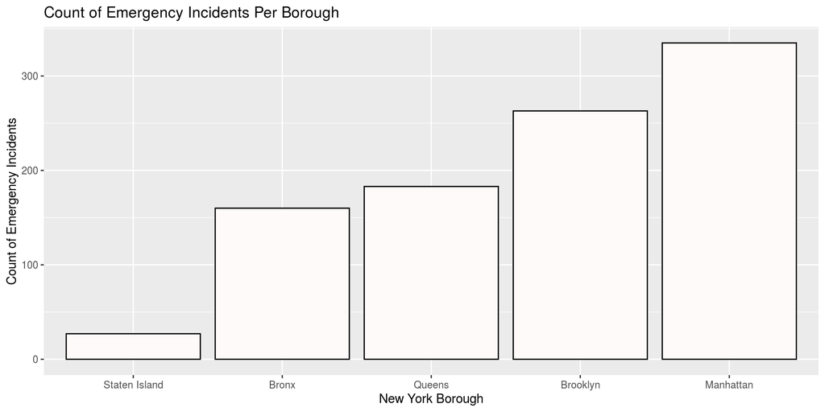

```r
# Sort Boroughs by Counts
sorted_boroughs = as.vector(as.data.frame(sort(table(my_data$borough)))$Var1)
my_data$borough =  factor(my_data$borough,levels = sorted_boroughs)

# Barplot
ggplot(my_data, aes(borough)) +
  geom_bar(fill = 'snow', color = 'black') +
  ggtitle('Count of Emergency Incidents Per Borough') +
  labs(x = 'New York Borough', y = 'Count of Emergency Incidents')
```

Queens has the third lowest count of emergency incidents. It has fewer incidents than Brooklyn and Manhattan.

### 2. Which incidents did Queens have less of, compared to the other boroughs?

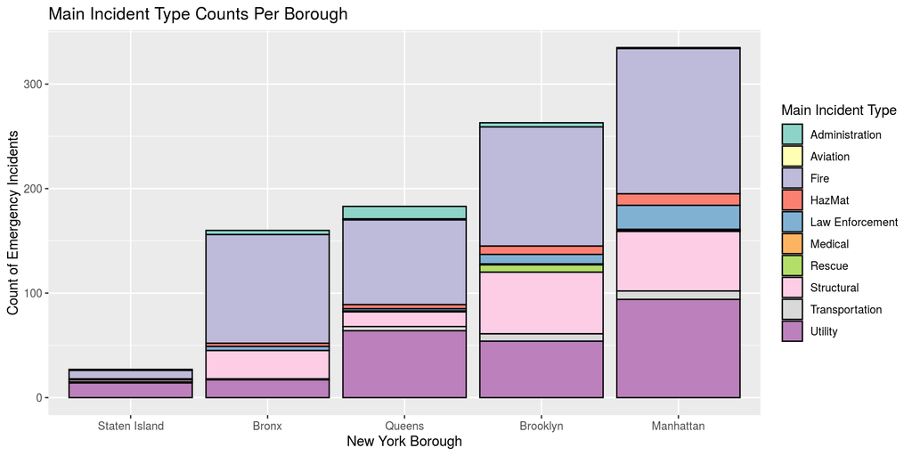

```r
# Stacked Barplot
ggplot(my_data, aes(fill = incident_type_main, x = borough)) +
  geom_bar(color = 'black') +
  ggtitle('Main Incident Type Counts Per Borough') +
  labs(x = 'New York Borough', y = 'Count of Emergency Incidents') +
  scale_fill_brewer(palette="Set3", name = 'Main Incident Type')
```

Queens has lower counts than at least two boroughs for all of the following incident (main types): transportation, structural, rescue, medical, law enforcement, hazmat, and fire.

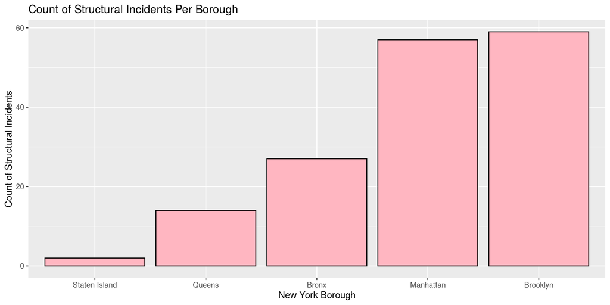

```r
# Subset
structural_incidents = subset(my_data, my_data$incident_type_main == 'Structural')

# Sort Boroughs by Counts
sorted_boroughs = as.vector(as.data.frame(sort(table(structural_incidents$borough)))$Var1)
structural_incidents$borough =  factor(structural_incidents$borough,levels = sorted_boroughs)

ggplot(structural_incidents, aes(borough)) +
  geom_bar(fill = 'lightpink', color = 'black') +
  ggtitle('Count of Structural Incidents Per Borough') +
  labs(x = 'New York Borough', y = 'Count of Structural Incidents')
```

Queens has the second lowest count of structural emergency incidents. Specifically, it has much lower counts than the Bronx, Manhattan, and Brooklyn.

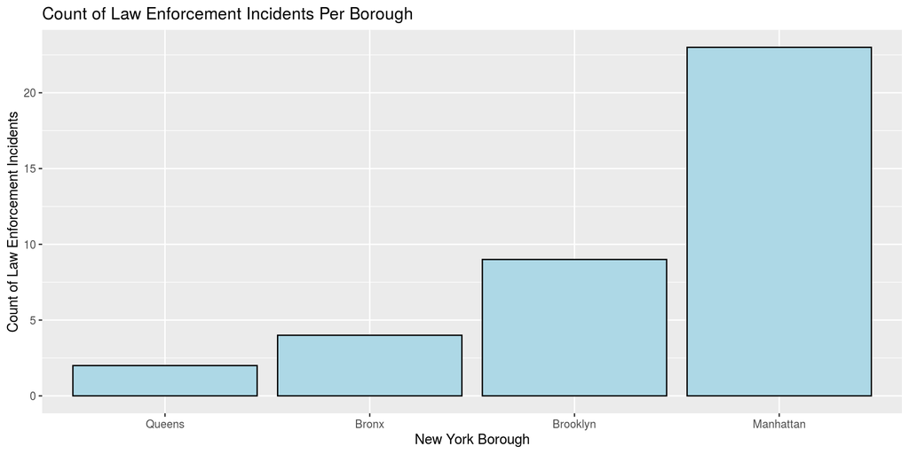

```r
le_incidents = subset(my_data, my_data$incident_type_main == 'Law Enforcement')

# Sort Boroughs by Counts
sorted_boroughs = as.vector(as.data.frame(sort(table(le_incidents$borough)))$Var1)
le_incidents$borough =  factor(le_incidents$borough,levels = sorted_boroughs)

ggplot(le_incidents, aes(borough)) +
  geom_bar(fill = 'lightblue', color = 'black') +
  ggtitle('Count of Law Enforcement Incidents Per Borough') +
  labs(x = 'New York Borough', y = 'Count of Law Enforcement Incidents')
```

Queens has the lowest count of law enforcement emergency incidents.

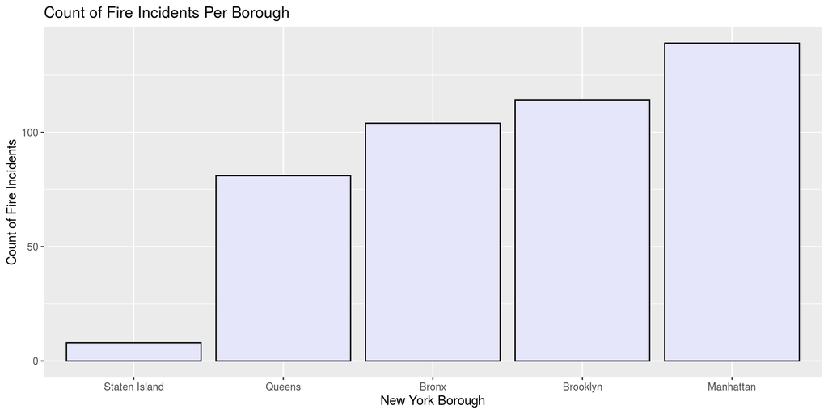

```r
fires = subset(my_data, my_data$incident_type_main == 'Fire')

# Sort Boroughs by Counts
sorted_boroughs = as.vector(as.data.frame(sort(table(fires$borough)))$Var1)
fires$borough =  factor(fires$borough,levels = sorted_boroughs)

ggplot(fires, aes(borough)) +
  geom_bar(fill = 'lavender', color = 'black') +
  ggtitle('Count of Fire Incidents Per Borough') +
  labs(x = 'New York Borough', y = 'Count of Fire Incidents')
```

Out of all the boroughs in New York City, Queens has the second lowest count of fire incidents. It has lower counts than the Bronx, Brooklyn, and Manhattan.

### 3. How do the counts of selected incident subtypes vary in Queens compared to other boroughs?

```r
# Value Counts for Incident Type Sub for Structural Incidents
sort(table(structural_incidents$incident_type_sub))
```

```
##
##                 Bridge                 Cracks          Sidewalk Shed
##                      1                      1                      1
##  Construction Accident                Parapet               Scaffold
##                      2                      2                      2
##             Demolition Life Safety Violations      Sidewalk Collapse
##                      3                      4                      5
##         Falling Debris      Stability Problem                  Crane
##                      8                     11                     12
##                  Other       Partial Collapse               Collapse
##                     15                     20                     35
##        Street Collapse
##                     37
```

There are a lot of structural incidents involving collapses of some sort.

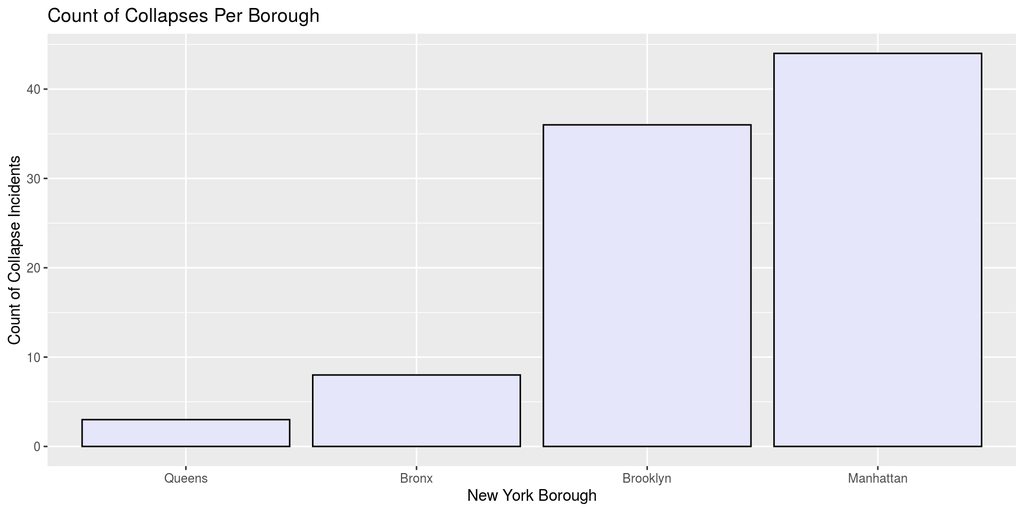

```r
collapse = subset(my_data, incident_type_sub %in% c('Collapse', 'Street Collapse', ' Partial Collapse'))

# Sort Boroughs by Counts
sorted_boroughs = as.vector(as.data.frame(sort(table(collapse$borough)))$Var1)
collapse$borough = factor(collapse$borough,levels = sorted_boroughs)

ggplot(collapse, aes(borough)) +
  geom_bar(fill = 'lavender', color = 'black') +
  ggtitle('Count of Collapses Per Borough') +
  labs(x = 'New York Borough', y = 'Count of Collapse Incidents')
```

Queens has the lowest count of structural collapses per borough.

```r
# Value Counts for Incident Type Sub for Utility Incidents
utility_incidents = subset(my_data, incident_type_main == 'Utility')
sort(table(utility_incidents$incident_type_sub))
```

```
##
##     Electric Overhead           Transformer Electric Feeder Cable
##                     1                     1                     2
##      Gas Main Rupture      Gas Service Line    Steam Service Line
##                     2                     2                     3
##     Gas High Pressure               Manhole      Gas Low Pressure
##                     4                     4                     6
##    Water Service Line         Sewer Service          Power Outage
##                    10                    22                    26
##                 Other            Steam Main            Water Main
##                    28                    54                    78
```

There are a lot of utility incidents involving steam and gas.

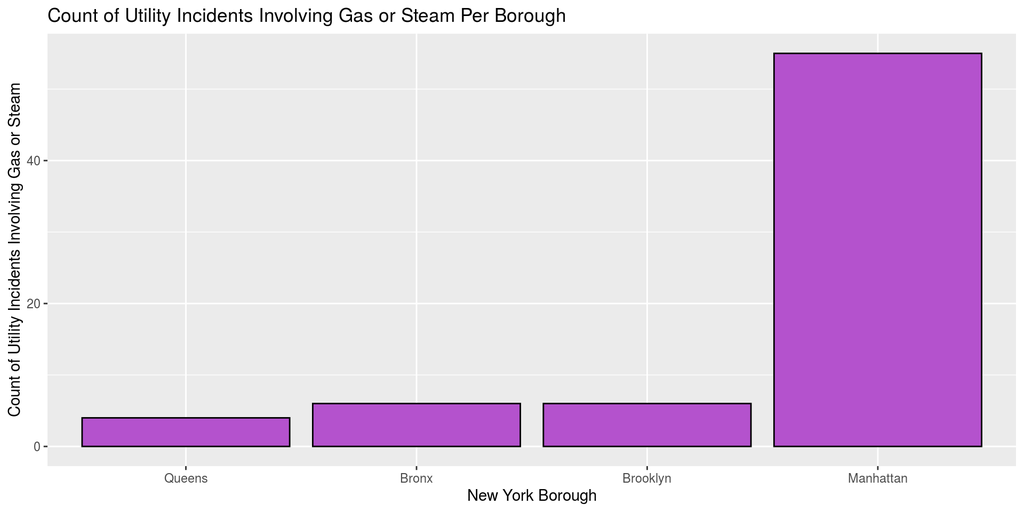

```r
gas_steam = subset(my_data, incident_type_sub %in% c('Steam Main', 'Gas Main Rupture',
                                                 'Gas Service Line', 'Gas Low Pressure',
                                                 'Gas High Pressure', 'Steam Service Line'))

# Sort Boroughs by Counts
sorted_boroughs = as.vector(as.data.frame(sort(table(gas_steam$borough)))$Var1)
gas_steam$borough = factor(gas_steam$borough,levels = sorted_boroughs)

ggplot(gas_steam, aes(borough)) +
  geom_bar(fill = 'mediumorchid3', color = 'black') +
  ggtitle('Count of Utility Incidents Involving Gas or Steam Per Borough') +
  labs(x = 'New York Borough', y = 'Count of Utility Incidents Involving Gas or Steam')
```

Queens has the lowest count of utility incidents involving gas or steam per borough.